# Project Code

Besler Besties

Author

Jamie Park, Lauren Lin, Jonny Myong, and Daniel Lee

Published

March 10, 2023

Abstract

*This file contains the code for the project on energy demand prediction, as part of the STAT303-2 course in Winter 2023*.

## 1 Data quality check / cleaning / preparation

### 1.1 Data quality check

By Daniel Lee

```python
import pandas as pd
from datetime import datetime
import seaborn as sns
import statsmodels.formula.api as smf
import statsmodels.api as sm
import matplotlib.pyplot as plt
import numpy as np
```

*The code below shows the distribution of the different variables we worked with for our analysis by showing visualizations and describing the relevant distribution information (.describe)*

```python
# Downloading the dataset
df = pd.read_csv('complete_dataset.csv')
df['date'] = pd.to_datetime(df['date'])
```

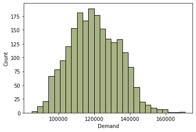

```python
# Plotting the distribution of demand data
sns.histplot(data=df['demand'], color='#8A9A5B')
plt.xlabel('Demand')
```

```python
# Seeing how many null values there are
print(df.isnull().sum())
```

```
date               0
demand             0
RRP                0
demand_pos_RRP     0
RRP_positive       0
demand_neg_RRP     0
RRP_negative       0
frac_at_neg_RRP    0
min_temperature    0
max_temperature    0
solar_exposure     1
rainfall           3
school_day         0
holiday            0
dtype: int64
```

```python
df.describe()
```

|  | demand | RRP | demand_pos_RRP | RRP_positive | demand_neg_RRP | RRP_negative | frac_at_neg_RRP | min_temperature | max_temperature | solar_exposure | rainfall |
| --- | --- | --- | --- | --- | --- | --- | --- | --- | --- | --- | --- |
| count | 2106.000000 | 2106.000000 | 2106.000000 | 2106.000000 | 2106.000000 | 2106.000000 | 2106.000000 | 2106.000000 | 2106.000000 | 2105.000000 | 2103.000000 |
| mean | 120035.476503 | 76.079554 | 119252.305055 | 76.553847 | 783.171448 | -2.686052 | 0.008547 | 11.582289 | 20.413200 | 14.743373 | 1.505944 |
| std | 13747.993761 | 130.246805 | 14818.631319 | 130.114184 | 3578.920686 | 19.485432 | 0.039963 | 4.313711 | 6.288693 | 7.945527 | 4.307897 |
| min | 85094.375000 | -6.076028 | 41988.240000 | 13.568986 | 0.000000 | -342.220000 | 0.000000 | 0.600000 | 9.000000 | 0.700000 | 0.000000 |
| 25% | 109963.650000 | 38.707040 | 109246.250000 | 39.117361 | 0.000000 | 0.000000 | 0.000000 | 8.500000 | 15.525000 | 8.200000 | 0.000000 |
| 50% | 119585.912500 | 66.596738 | 119148.082500 | 66.869058 | 0.000000 | 0.000000 | 0.000000 | 11.300000 | 19.100000 | 12.700000 | 0.000000 |
| 75% | 130436.006250 | 95.075012 | 130119.477500 | 95.130181 | 0.000000 | 0.000000 | 0.000000 | 14.600000 | 23.900000 | 20.700000 | 0.800000 |
| max | 170653.840000 | 4549.645105 | 170653.840000 | 4549.645105 | 57597.595000 | 0.000000 | 0.625000 | 28.000000 | 43.500000 | 33.300000 | 54.600000 |

### 1.2 Data cleaning and Data Preparation

*By Lauren Lin*

From the data quality check we realized that:

1. There were 4 NA values in this dataset, 1 for solar_exposure and 3 for rainfall, so we imputed them with the means of their respective variables. For example, since the mean of df[‘solar_exposure’] is 14.74337292161519, we replaced the NA value of solar_exposure with 14.74337292161519.
2. In addition to imputing NA values, we changed the values of’school_day’ and ‘holiday’ (‘N’ and ‘Y’) to a binary of 0 and 1 so that they could be added to our regression model.

The code below implements the above cleaning.

```python
# Changing values to more easily fit by changing to 1s and 0s instead of Y or N
df['school_day'] = df['school_day'].apply(lambda x: 1 if x == 'Y' else 0)
df['holiday'] = df['holiday'].apply(lambda x: 1 if x == 'Y' else 0)
```

```python
# 4 NAN values that were imputed
print(df['solar_exposure'].mean())
df.at[1060, 'solar_exposure']=14.74337292161519

print(df['rainfall'].mean())
df.at[161, 'rainfall']=1.505943889681408
df.at[1377, 'rainfall']=1.505943889681408
df.at[1378, 'rainfall']=1.505943889681408
```

```
14.74337292161519
1.505943889681408
```

## 2 Exploratory data analysis

*By Lauren Lin*

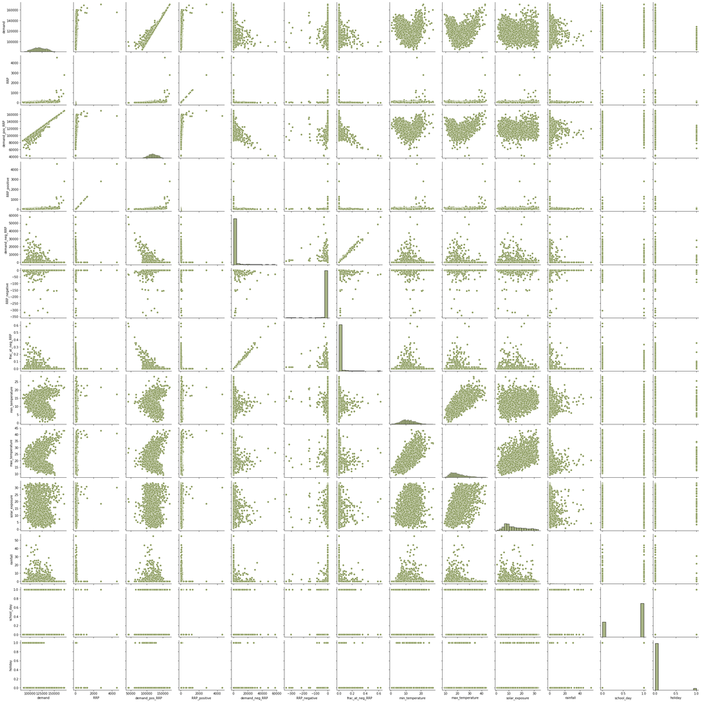

```python
# Make pairplot of the dataframe to explore relationships between variables
sns.pairplot(df, plot_kws={'color':'#8A9A5B'}, diag_kws={'color':'#8A9A5B'})
```

- There is an obvious quadratic relationship between demand and min_temperature and demand and max_temperature
- It seems that solar_exposure might also have a quadratic relationship with demand, but a residual plot should be graphed to confirm
- Whether rainfall, school_day, and/or holiday have an effect on demand is unclear. They should be included in the first model so that we can check their p-values.

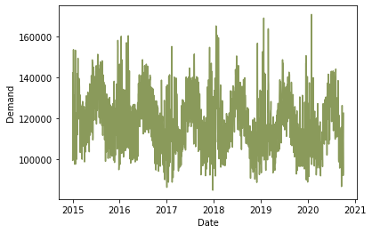

```python
# Looking at relationship between date and demand
sns.lineplot(x='date', y='demand', data=df, color = '#8A9A5B')
plt.xlabel('Date')
plt.ylabel('Demand')
```

- The repeating patterns in the lineplot of demand against date indicate autocorrelation.

```python
from statsmodels.stats.outliers_influence import variance_inflation_factor
from statsmodels.tools.tools import add_constant

# Calculating VIF

X = df[['max_temperature', 'min_temperature', 'solar_exposure', 'holiday', 'rainfall']]
X = add_constant(X, has_constant='add')
vif_data = pd.DataFrame()
vif_data['feature'] = X.columns

for i in range(len(X.columns)):
    X.columns[i]
    vif_data.loc[i,'VIF'] = variance_inflation_factor(X.values, i)

print(vif_data)
```

```
           feature        VIF
0            const  12.478907
1  max_temperature   2.768200
2  min_temperature   2.056258
3   solar_exposure   1.571803
4          holiday   1.005603
5         rainfall   1.050010
```

## 3 Developing the model

*By Jonny Myong and Jamie Park*

```python
# Model 1 : multiple linear regression with max temp, min temp, solar exposure, school_day, and holiday
ols_object = smf.ols(formula = 'demand~max_temperature+min_temperature+solar_exposure+school_day+holiday+rainfall', data = df)
model1 = ols_object.fit()
print(model1.summary())
```

```
                            OLS Regression Results
==============================================================================
Dep. Variable:                 demand   R-squared:                       0.166
Model:                            OLS   Adj. R-squared:                  0.163
Method:                 Least Squares   F-statistic:                     69.55
Date:                Mon, 13 Mar 2023   Prob (F-statistic):           3.46e-79
Time:                        17:10:11   Log-Likelihood:                -22864.
No. Observations:                2106   AIC:                         4.574e+04
Df Residuals:                    2099   BIC:                         4.578e+04
Df Model:                           6
Covariance Type:            nonrobust
===================================================================================
                      coef    std err          t      P>|t|      [0.025      0.975]
-----------------------------------------------------------------------------------
Intercept        1.235e+05   1094.925    112.762      0.000    1.21e+05    1.26e+05
max_temperature   615.4166     72.530      8.485      0.000     473.179     757.655
min_temperature  -660.2250     91.117     -7.246      0.000    -838.915    -481.535
solar_exposure   -589.0918     43.307    -13.603      0.000    -674.022    -504.162
school_day       1808.5191    604.516      2.992      0.003     623.006    2994.032
holiday         -1.619e+04   1484.457    -10.907      0.000   -1.91e+04   -1.33e+04
rainfall         -210.6746     65.267     -3.228      0.001    -338.669     -82.680
==============================================================================
Omnibus:                       32.683   Durbin-Watson:                   0.721
Prob(Omnibus):                  0.000   Jarque-Bera (JB):               33.822
Skew:                           0.302   Prob(JB):                     4.52e-08
Kurtosis:                       3.144   Cond. No.                         160.
==============================================================================

Notes:
[1] Standard Errors assume that the covariance matrix of the errors is correctly specified.
```

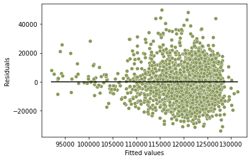

```python
# Plotting residuals against fitted values
sns.scatterplot(x=model1.fittedvalues, y=model1.resid, color = '#8A9A5B')
sns.lineplot(x=[model1.fittedvalues.min(), model1.fittedvalues.max()], y=[0,0], color='black')
plt.xlabel('Fitted values')
plt.ylabel('Residuals')
```

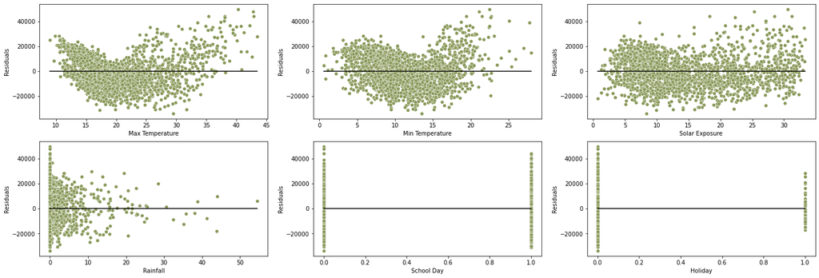

```python
# Visualizing residuals of all the predictor variables
fig = plt.figure(figsize=(24, 8))
plt.subplot(2, 3, 1)
sns.scatterplot(x=df.max_temperature, y=model1.resid, color = '#8A9A5B')
sns.lineplot(x=[df.max_temperature.min(), df.max_temperature.max()], y=[0,0], color='black')
plt.xlabel('Max Temperature')
plt.ylabel('Residuals')

plt.subplot(2, 3, 2)
sns.scatterplot(x=df.min_temperature, y=model1.resid, color = '#8A9A5B')
sns.lineplot(x=[df.min_temperature.min(), df.min_temperature.max()], y=[0,0], color='black')
plt.xlabel('Min Temperature')
plt.ylabel('Residuals')

plt.subplot(2, 3, 3)
sns.scatterplot(x=df.solar_exposure, y=model1.resid, color = '#8A9A5B')
sns.lineplot(x=[df.solar_exposure.min(), df.solar_exposure.max()], y=[0,0], color='black')
plt.xlabel('Solar Exposure')
plt.ylabel('Residuals')

plt.subplot(2, 3, 4)
sns.scatterplot(x=df.rainfall, y=model1.resid, color = '#8A9A5B')
sns.lineplot(x=[df.rainfall.min(), df.rainfall.max()], y=[0,0], color='black')
plt.xlabel('Rainfall')
plt.ylabel('Residuals')

plt.subplot(2, 3, 5)
sns.scatterplot(x=df.school_day, y=model1.resid, color = '#8A9A5B')
sns.lineplot(x=[df.school_day.min(), df.school_day.max()], y=[0,0], color='black')
plt.xlabel('School Day')
plt.ylabel('Residuals')

plt.subplot(2, 3, 6)
sns.scatterplot(x=df.holiday, y=model1.resid, color = '#8A9A5B')
sns.lineplot(x=[df.holiday.min(), df.holiday.max()], y=[0,0], color='black')
plt.xlabel('Holiday')
plt.ylabel('Residuals')
```

#### 3.0.1 Model 1 Conclusions:

- The response variable is heteroscedastic
- max temperature, min temperature, and solar exposure are quadratic

```python
# Model 2 : np.log(y) to resolve heterscedasticity
# and max_temperature, min_temperature, solar_exposure squared to fit linearity assumptions
ols_object = smf.ols(formula = 'np.log(demand)~max_temperature+I(max_temperature**2)+min_temperature+I(min_temperature**2)+solar_exposure+I(solar_exposure**2)+school_day+holiday+rainfall', data = df)
model2 = ols_object.fit()
print(model2.summary())

pred_demand = model2.predict(df)
print(np.sqrt((df['demand']-pred_demand)**2).mean())
```

```
                            OLS Regression Results
==============================================================================
Dep. Variable:         np.log(demand)   R-squared:                       0.489
Model:                            OLS   Adj. R-squared:                  0.486
Method:                 Least Squares   F-statistic:                     222.6
Date:                Mon, 13 Mar 2023   Prob (F-statistic):          1.33e-297
Time:                        17:10:12   Log-Likelihood:                 2275.3
No. Observations:                2106   AIC:                            -4531.
Df Residuals:                    2096   BIC:                            -4474.
Df Model:                           9
Covariance Type:            nonrobust
===========================================================================================
                              coef    std err          t      P>|t|      [0.025      0.975]
-------------------------------------------------------------------------------------------
Intercept                  12.4022      0.021    603.055      0.000      12.362      12.443
max_temperature            -0.0454      0.002    -22.021      0.000      -0.049      -0.041
I(max_temperature ** 2)     0.0010   4.06e-05     24.432      0.000       0.001       0.001
min_temperature            -0.0292      0.002    -14.373      0.000      -0.033      -0.025
I(min_temperature ** 2)     0.0011   7.89e-05     14.569      0.000       0.001       0.001
solar_exposure             -0.0104      0.001     -9.233      0.000      -0.013      -0.008
I(solar_exposure ** 2)      0.0002   3.15e-05      7.276      0.000       0.000       0.000
school_day                  0.0295      0.004      7.393      0.000       0.022       0.037
holiday                    -0.1137      0.010    -11.652      0.000      -0.133      -0.095
rainfall                   -0.0021      0.000     -4.988      0.000      -0.003      -0.001
==============================================================================
Omnibus:                       45.891   Durbin-Watson:                   1.026
Prob(Omnibus):                  0.000   Jarque-Bera (JB):               48.194
Skew:                          -0.363   Prob(JB):                     3.43e-11
Kurtosis:                       2.850   Cond. No.                     7.64e+03
==============================================================================

Notes:
[1] Standard Errors assume that the covariance matrix of the errors is correctly specified.
[2] The condition number is large, 7.64e+03. This might indicate that there are
strong multicollinearity or other numerical problems.
120023.78753370707
```

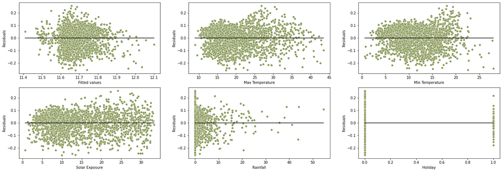

```python
# Visualizing residuals of all the predictor variables again
fig = plt.figure(figsize=(24, 8))
plt.subplot(2, 3, 1)
sns.scatterplot(x=model2.fittedvalues, y=model2.resid, color = '#8A9A5B')
sns.lineplot(x=[model2.fittedvalues.min(), model2.fittedvalues.max()], y=[0,0], color='black')
plt.xlabel('Fitted values')
plt.ylabel('Residuals')

plt.subplot(2, 3, 2)
sns.scatterplot(x=df.max_temperature, y=model2.resid, color = '#8A9A5B')
sns.lineplot(x=[df.max_temperature.min(), df.max_temperature.max()], y=[0,0], color='black')
plt.xlabel('Max Temperature')
plt.ylabel('Residuals')

plt.subplot(2, 3, 3)
sns.scatterplot(x=df.min_temperature, y=model2.resid, color = '#8A9A5B')
sns.lineplot(x=[df.min_temperature.min(), df.min_temperature.max()], y=[0,0], color='black')
plt.xlabel('Min Temperature')
plt.ylabel('Residuals')

plt.subplot(2, 3, 4)
sns.scatterplot(x=df.solar_exposure, y=model2.resid, color = '#8A9A5B')
sns.lineplot(x=[df.solar_exposure.min(), df.solar_exposure.max()], y=[0,0], color='black')
plt.xlabel('Solar Exposure')
plt.ylabel('Residuals')

plt.subplot(2, 3, 5)
sns.scatterplot(x=df.rainfall, y=model2.resid, color = '#8A9A5B')
sns.lineplot(x=[df.rainfall.min(), df.rainfall.max()], y=[0,0], color='black')
plt.xlabel('Rainfall')
plt.ylabel('Residuals')

plt.subplot(2, 3, 6)
sns.scatterplot(x=df.holiday, y=model2.resid, color = '#8A9A5B')
sns.lineplot(x=[df.holiday.min(), df.holiday.max()], y=[0,0], color='black')
plt.xlabel('Holiday')
plt.ylabel('Residuals')
```

#### 3.0.2 Model 2 Conclusions:

- Our R-squared significantly better
- The residual plots indicate that linear assumptions have been satisfied

```python
# Model 2.5 : checking if interaction term of max_temperature*holiday improves our model
ols_object = smf.ols(formula = 'np.log(demand)~max_temperature+I(max_temperature**2)+min_temperature+\
I(min_temperature**2)+solar_exposure+I(solar_exposure**2)+holiday*max_temperature+school_day+holiday+\
rainfall', data = df)

model25 = ols_object.fit()
print(model25.summary())

pred = model25.predict(df)
print(np.sqrt((df['demand']-pred)**2).mean())
```

```
                            OLS Regression Results
==============================================================================
Dep. Variable:         np.log(demand)   R-squared:                       0.489
Model:                            OLS   Adj. R-squared:                  0.486
Method:                 Least Squares   F-statistic:                     200.2
Date:                Mon, 13 Mar 2023   Prob (F-statistic):          1.97e-296
Time:                        17:10:13   Log-Likelihood:                 2275.3
No. Observations:                2106   AIC:                            -4529.
Df Residuals:                    2095   BIC:                            -4466.
Df Model:                          10
Covariance Type:            nonrobust
===========================================================================================
                              coef    std err          t      P>|t|      [0.025      0.975]
-------------------------------------------------------------------------------------------
Intercept                  12.4023      0.021    602.855      0.000      12.362      12.443
max_temperature            -0.0454      0.002    -22.002      0.000      -0.049      -0.041
I(max_temperature ** 2)     0.0010   4.06e-05     24.422      0.000       0.001       0.001
min_temperature            -0.0292      0.002    -14.341      0.000      -0.033      -0.025
I(min_temperature ** 2)     0.0011    7.9e-05     14.540      0.000       0.001       0.001
solar_exposure             -0.0104      0.001     -9.195      0.000      -0.013      -0.008
I(solar_exposure ** 2)      0.0002   3.16e-05      7.235      0.000       0.000       0.000
holiday                    -0.1253      0.046     -2.718      0.007      -0.216      -0.035
holiday:max_temperature     0.0005      0.002      0.256      0.798      -0.004       0.005
school_day                  0.0295      0.004      7.395      0.000       0.022       0.037
rainfall                   -0.0021      0.000     -4.985      0.000      -0.003      -0.001
==============================================================================
Omnibus:                       45.955   Durbin-Watson:                   1.026
Prob(Omnibus):                  0.000   Jarque-Bera (JB):               48.260
Skew:                          -0.363   Prob(JB):                     3.32e-11
Kurtosis:                       2.849   Cond. No.                     1.71e+04
==============================================================================

Notes:
[1] Standard Errors assume that the covariance matrix of the errors is correctly specified.
[2] The condition number is large, 1.71e+04. This might indicate that there are
strong multicollinearity or other numerical problems.
120023.78753370687
```

*By Jonny Myong and Jamie Park*

### 3.2 Removing influential points

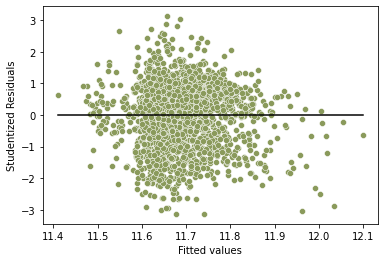

```python
# Plotting studentized residuals
out = model2.outlier_test()

sns.scatterplot(x = (model2.fittedvalues), y=(out.student_resid), color = '#8A9A5B')
sns.lineplot(x = [model2.fittedvalues.min(), model2.fittedvalues.max()], y = [0,0], color = 'black')
plt.xlabel('Fitted values')
plt.ylabel('Studentized Residuals')
```

```python
# Finding the number of outliers
np.sum((np.abs(out.student_resid)>3))
```

```
6
```

```python
# Computing the leverage statistic for each observation
influence = model2.get_influence()
leverage = influence.hat_matrix_diag
```

```python
out = model2.outlier_test()
```

```python
# Finding the number of high leverage points
average_leverage = (model2.df_model+1)/model2.nobs
high_leverage_threshold = 4*average_leverage
np.sum(leverage>high_leverage_threshold)
```

```
41
```

```python
# Dropping influential points from data
df_filtered = df.drop(np.intersect1d(np.where(np.abs(out.student_resid)>3)[0],
                                           (np.where(leverage>high_leverage_threshold)[0])))
```

```python
# Finding the number of influential point(s)
df.shape[0]-df_filtered.shape[0]
```

```
1
```

```python
ols_object = smf.ols(formula = 'np.log(demand)~max_temperature+I(max_temperature**2)+min_temperature+I(min_temperature**2)+solar_exposure+I(solar_exposure**2)+school_day+holiday+rainfall', data = df_filtered)
model3 = ols_object.fit()
model3.summary()
```

OLS Regression Results

| Dep. Variable: | np.log(demand) | R-squared: | 0.491 |
| --- | --- | --- | --- |
| Model: | OLS | Adj. R-squared: | 0.489 |
| Method: | Least Squares | F-statistic: | 224.5 |
| Date: | Mon, 13 Mar 2023 | Prob (F-statistic): | 1.90e-299 |
| Time: | 17:10:16 | Log-Likelihood: | 2278.4 |
| No. Observations: | 2105 | AIC: | -4537. |
| Df Residuals: | 2095 | BIC: | -4480. |
| Df Model: | 9 |  |  |
| Covariance Type: | nonrobust |  |  |

|  | coef | std err | t | P>\|t\| | [0.025 | 0.975] |
| --- | --- | --- | --- | --- | --- | --- |
| Intercept | 12.4076 | 0.021 | 602.227 | 0.000 | 12.367 | 12.448 |
| max_temperature | -0.0454 | 0.002 | -22.031 | 0.000 | -0.049 | -0.041 |
| I(max_temperature ** 2) | 0.0010 | 4.05e-05 | 24.390 | 0.000 | 0.001 | 0.001 |
| min_temperature | -0.0303 | 0.002 | -14.714 | 0.000 | -0.034 | -0.026 |
| I(min_temperature ** 2) | 0.0012 | 8.06e-05 | 14.911 | 0.000 | 0.001 | 0.001 |
| solar_exposure | -0.0104 | 0.001 | -9.307 | 0.000 | -0.013 | -0.008 |
| I(solar_exposure ** 2) | 0.0002 | 3.15e-05 | 7.393 | 0.000 | 0.000 | 0.000 |
| school_day | 0.0293 | 0.004 | 7.368 | 0.000 | 0.022 | 0.037 |
| holiday | -0.1140 | 0.010 | -11.705 | 0.000 | -0.133 | -0.095 |
| rainfall | -0.0021 | 0.000 | -5.002 | 0.000 | -0.003 | -0.001 |

| Omnibus: | 47.690 | Durbin-Watson: | 1.026 |
| --- | --- | --- | --- |
| Prob(Omnibus): | 0.000 | Jarque-Bera (JB): | 49.970 |
| Skew: | -0.367 | Prob(JB): | 1.41e-11 |
| Kurtosis: | 2.828 | Cond. No. | 7.66e+03 |

Notes:  
[1] Standard Errors assume that the covariance matrix of the errors is correctly specified.  
[2] The condition number is large, 7.66e+03. This might indicate that there are  
strong multicollinearity or other numerical problems.

### 3.3 Autocorrelation Section

*By Jamie Park*

Besides all of the code above, we also conducted autocorrelation to see if adding lag better furthered our results

```python
# Changing variables based on earlier observations to prepare for autocorrelation
df_filtered['demand'] = np.log(df_filtered['demand'])
df_filtered['max_temperature_squared'] = (df_filtered['max_temperature'])**2
df_filtered['min_temperature_squared'] = (df_filtered['min_temperature'])**2
df_filtered['solar_exposure_squared'] = (df_filtered['solar_exposure'])**2
```

```python
# Dropping variables irrelevant to our model-building
df_filtered = df_filtered.drop(['RRP', 'demand_pos_RRP', 'RRP_positive',
                                'demand_neg_RRP', 'RRP_negative', 'frac_at_neg_RRP'], axis=1)
```

```python
# Defining base_vars to hold our main predictor variables
base_vars = ['max_temperature', 'max_temperature_squared', 'min_temperature', \
             'min_temperature_squared', 'solar_exposure', 'solar_exposure_squared', \
             'school_day','holiday', 'rainfall']
```

```python
# Defining functions utilized for autocorrelation
import numpy.ma as ma
from scipy.stats.stats import pearsonr, normaltest
from scipy.spatial.distance import correlation

# Builds a model with data up until a certain date
def build_model(features):
    X=sm.add_constant(df_filtered[df_filtered['date']<date][features])
    y=df_filtered[df_filtered['date']<date]['demand']
    model = sm.OLS(y, X, missing='drop').fit()
    predictions = model.predict(X)
    res = y-predictions
    return model, res

# Plots the residuals against time
def plt_residual(res):
    plt.plot(range(len(res)), res, color = '#8A9A5B')
    plt.ylabel('Residual')
    plt.xlabel('Day')
```

```python
# Performing autocorrelation on 2019 data
# Creating a datetime index of every day in 2019

from datetime import date, timedelta

sdate = date(2019,1,1)
edate = date(2020,1,1)
all_dates = pd.date_range(sdate, edate-timedelta(days=1), freq='d')
```

```python
# Defining get_rmse to return the RMSE and energy demand predictions for every day in 2019
# given lags

def get_rmse(lags):
    predictions = pd.DataFrame()
    sse = 0
    for date in all_dates:
        model, residuals = build_model(base_vars+lags)
        subset = df_filtered[df_filtered['date'] == date]
        temp = model.predict(sm.add_constant(subset[base_vars+lags], has_constant='add'))
        sse += ((np.exp(subset['demand']) - np.exp(temp.values))**2).sum()
        predictions = pd.concat([predictions, temp])
    print(model.summary())

    return np.sqrt(sse/365), predictions
```

```python
# Systematically going through 1_day to 6_day lags (every day)
# to observe which increase(s) R-squared and decrease(s) RMSE the most

lags = []
days = []
rmses = []
for num in np.arange(1, 7, 1):
    var_name = 'demand_lag_' + str(num) + '_day'
    df_filtered[var_name] = df_filtered['demand'].shift(num)

    days.append(num)
    rmses.append(get_rmse([var_name]))

lag_models = pd.DataFrame({'day_lag':days , 'rmse':rmses})
lag_models
```

```
                            OLS Regression Results
==============================================================================
Dep. Variable:                 demand   R-squared:                       0.627
Model:                            OLS   Adj. R-squared:                  0.625
Method:                 Least Squares   F-statistic:                     304.3
Date:                Mon, 13 Mar 2023   Prob (F-statistic):               0.00
Time:                        17:15:12   Log-Likelihood:                 2266.3
No. Observations:                1823   AIC:                            -4511.
Df Residuals:                    1812   BIC:                            -4450.
Df Model:                          10
Covariance Type:            nonrobust
===========================================================================================
                              coef    std err          t      P>|t|      [0.025      0.975]
-------------------------------------------------------------------------------------------
const                       6.6301      0.217     30.615      0.000       6.205       7.055
max_temperature            -0.0350      0.002    -18.081      0.000      -0.039      -0.031
max_temperature_squared     0.0008   3.78e-05     20.897      0.000       0.001       0.001
min_temperature            -0.0099      0.002     -4.873      0.000      -0.014      -0.006
min_temperature_squared     0.0003   7.95e-05      4.230      0.000       0.000       0.000
solar_exposure             -0.0064      0.001     -6.209      0.000      -0.008      -0.004
solar_exposure_squared      0.0001   2.85e-05      5.262      0.000    9.41e-05       0.000
school_day                  0.0129      0.004      3.280      0.001       0.005       0.021
holiday                    -0.0815      0.009     -8.953      0.000      -0.099      -0.064
rainfall                   -0.0022      0.000     -4.999      0.000      -0.003      -0.001
demand_lag_1_day            0.4728      0.018     26.776      0.000       0.438       0.507
==============================================================================
Omnibus:                       38.761   Durbin-Watson:                   1.507
Prob(Omnibus):                  0.000   Jarque-Bera (JB):               38.867
Skew:                          -0.333   Prob(JB):                     3.63e-09
Kurtosis:                       2.739   Cond. No.                     8.99e+04
==============================================================================

Notes:
[1] Standard Errors assume that the covariance matrix of the errors is correctly specified.
[2] The condition number is large, 8.99e+04. This might indicate that there are
strong multicollinearity or other numerical problems.
                            OLS Regression Results
==============================================================================
Dep. Variable:                 demand   R-squared:                       0.484
Model:                            OLS   Adj. R-squared:                  0.481
```

[output cut: 53 more lines]

```
school_day                  0.0220      0.005      4.755      0.000       0.013       0.031
holiday                    -0.1185      0.011    -11.138      0.000      -0.139      -0.098
rainfall                   -0.0025      0.001     -4.889      0.000      -0.004      -0.002
demand_lag_3_day           -0.0071      0.018     -0.387      0.699      -0.043       0.029
==============================================================================
Omnibus:                       44.334   Durbin-Watson:                   1.045
Prob(Omnibus):                  0.000   Jarque-Bera (JB):               46.865
Skew:                          -0.385   Prob(JB):                     6.66e-11
Kurtosis:                       2.847   Cond. No.                     7.80e+04
==============================================================================

Notes:
[1] Standard Errors assume that the covariance matrix of the errors is correctly specified.
[2] The condition number is large, 7.8e+04. This might indicate that there are
strong multicollinearity or other numerical problems.
```

```
                            OLS Regression Results
==============================================================================
Dep. Variable:                 demand   R-squared:                       0.478
Model:                            OLS   Adj. R-squared:                  0.475
Method:                 Least Squares   F-statistic:                     165.8
Date:                Mon, 13 Mar 2023   Prob (F-statistic):          4.01e-247
Time:                        17:15:26   Log-Likelihood:                 1958.4
No. Observations:                1820   AIC:                            -3895.
Df Residuals:                    1809   BIC:                            -3834.
Df Model:                          10
Covariance Type:            nonrobust
===========================================================================================
                              coef    std err          t      P>|t|      [0.025      0.975]
-------------------------------------------------------------------------------------------
const                      12.2969      0.219     56.221      0.000      11.868      12.726
max_temperature            -0.0456      0.002    -20.215      0.000      -0.050      -0.041
max_temperature_squared     0.0010   4.42e-05     22.406      0.000       0.001       0.001
min_temperature            -0.0284      0.002    -12.503      0.000      -0.033      -0.024
min_temperature_squared     0.0011   8.76e-05     13.081      0.000       0.001       0.001
solar_exposure             -0.0098      0.001     -8.146      0.000      -0.012      -0.007
solar_exposure_squared      0.0002   3.37e-05      6.266      0.000       0.000       0.000
school_day                  0.0218      0.005      4.723      0.000       0.013       0.031
holiday                    -0.1187      0.011    -11.147      0.000      -0.140      -0.098
rainfall                   -0.0025      0.001     -4.853      0.000      -0.004      -0.001
demand_lag_4_day            0.0092      0.018      0.509      0.611      -0.026       0.045
==============================================================================
Omnibus:                       46.779   Durbin-Watson:                   1.044
Prob(Omnibus):                  0.000   Jarque-Bera (JB):               49.533
Skew:                          -0.396   Prob(JB):                     1.75e-11
Kurtosis:                       2.835   Cond. No.                     7.65e+04
==============================================================================

Notes:
[1] Standard Errors assume that the covariance matrix of the errors is correctly specified.
[2] The condition number is large, 7.65e+04. This might indicate that there are
strong multicollinearity or other numerical problems.
                            OLS Regression Results
==============================================================================
Dep. Variable:                 demand   R-squared:                       0.483
Model:                            OLS   Adj. R-squared:                  0.481
```

[output cut: 53 more lines]

```
school_day                  0.0185      0.004      4.337      0.000       0.010       0.027
holiday                    -0.1154      0.010    -11.786      0.000      -0.135      -0.096
rainfall                   -0.0021      0.000     -4.409      0.000      -0.003      -0.001
demand_lag_6_day            0.3036      0.017     18.114      0.000       0.271       0.336
==============================================================================
Omnibus:                       62.627   Durbin-Watson:                   1.260
Prob(Omnibus):                  0.000   Jarque-Bera (JB):               68.349
Skew:                          -0.461   Prob(JB):                     1.44e-15
Kurtosis:                       3.225   Cond. No.                     7.68e+04
==============================================================================

Notes:
[1] Standard Errors assume that the covariance matrix of the errors is correctly specified.
[2] The condition number is large, 7.68e+04. This might indicate that there are
strong multicollinearity or other numerical problems.
```

```
StopIteration:
```

```
StopIteration:
```

```python
# Systematically going through 7_day to 28_day lags (every week)
# to observe which increase(s) R-squared and decrease(s) RMSE the most

lags = []
days = []
rmses = []
for num in np.arange(7, 29, 7):
    var_name = 'demand_lag_' + str(num) + '_day'
    lags.append(var_name)
    df_filtered[var_name] = df_filtered['demand'].shift(num)

    days.append(num)
    rmses.append(get_rmse([var_name]))

lag_models = pd.DataFrame({'day_lag':days , 'rmse':rmses})
lag_models
```

```
                            OLS Regression Results
==============================================================================
Dep. Variable:                 demand   R-squared:                       0.691
Model:                            OLS   Adj. R-squared:                  0.689
Method:                 Least Squares   F-statistic:                     403.1
Date:                Mon, 13 Mar 2023   Prob (F-statistic):               0.00
Time:                        17:15:47   Log-Likelihood:                 2431.1
No. Observations:                1817   AIC:                            -4840.
Df Residuals:                    1806   BIC:                            -4780.
Df Model:                          10
Covariance Type:            nonrobust
===========================================================================================
                              coef    std err          t      P>|t|      [0.025      0.975]
-------------------------------------------------------------------------------------------
const                       6.4666      0.170     38.147      0.000       6.134       6.799
max_temperature            -0.0382      0.002    -21.897      0.000      -0.042      -0.035
max_temperature_squared     0.0009   3.43e-05     24.821      0.000       0.001       0.001
min_temperature            -0.0229      0.002    -13.141      0.000      -0.026      -0.019
min_temperature_squared     0.0010   6.71e-05     14.372      0.000       0.001       0.001
solar_exposure             -0.0056      0.001     -5.977      0.000      -0.007      -0.004
solar_exposure_squared      0.0001   2.61e-05      4.400      0.000    6.36e-05       0.000
school_day                  0.0144      0.004      4.046      0.000       0.007       0.021
holiday                    -0.1238      0.008    -15.109      0.000      -0.140      -0.108
rainfall                   -0.0023      0.000     -5.887      0.000      -0.003      -0.002
demand_lag_7_day            0.4947      0.014     35.222      0.000       0.467       0.522
==============================================================================
Omnibus:                       74.269   Durbin-Watson:                   1.060
Prob(Omnibus):                  0.000   Jarque-Bera (JB):              151.498
Skew:                          -0.272   Prob(JB):                     1.27e-33
Kurtosis:                       4.306   Cond. No.                     7.69e+04
==============================================================================

Notes:
[1] Standard Errors assume that the covariance matrix of the errors is correctly specified.
[2] The condition number is large, 7.69e+04. This might indicate that there are
strong multicollinearity or other numerical problems.
                            OLS Regression Results
==============================================================================
Dep. Variable:                 demand   R-squared:                       0.663
Model:                            OLS   Adj. R-squared:                  0.661
```

[output cut: 53 more lines]

```
school_day                  0.0213      0.004      5.641      0.000       0.014       0.029
holiday                    -0.1118      0.009    -12.984      0.000      -0.129      -0.095
rainfall                   -0.0017      0.000     -4.060      0.000      -0.003      -0.001
demand_lag_21_day           0.4511      0.015     30.676      0.000       0.422       0.480
==============================================================================
Omnibus:                       29.165   Durbin-Watson:                   0.989
Prob(Omnibus):                  0.000   Jarque-Bera (JB):               53.158
Skew:                          -0.054   Prob(JB):                     2.86e-12
Kurtosis:                       3.834   Cond. No.                     7.59e+04
==============================================================================

Notes:
[1] Standard Errors assume that the covariance matrix of the errors is correctly specified.
[2] The condition number is large, 7.59e+04. This might indicate that there are
strong multicollinearity or other numerical problems.
```

```
                            OLS Regression Results
==============================================================================
Dep. Variable:                 demand   R-squared:                       0.645
Model:                            OLS   Adj. R-squared:                  0.643
Method:                 Least Squares   F-statistic:                     324.7
Date:                Mon, 13 Mar 2023   Prob (F-statistic):               0.00
Time:                        17:16:01   Log-Likelihood:                 2283.8
No. Observations:                1796   AIC:                            -4546.
Df Residuals:                    1785   BIC:                            -4485.
Df Model:                          10
Covariance Type:            nonrobust
===========================================================================================
                              coef    std err          t      P>|t|      [0.025      0.975]
-------------------------------------------------------------------------------------------
const                       7.2102      0.181     39.907      0.000       6.856       7.565
max_temperature            -0.0378      0.002    -20.094      0.000      -0.041      -0.034
max_temperature_squared     0.0008   3.69e-05     22.894      0.000       0.001       0.001
min_temperature            -0.0262      0.002    -14.063      0.000      -0.030      -0.023
min_temperature_squared     0.0011   7.22e-05     15.335      0.000       0.001       0.001
solar_exposure             -0.0118      0.001    -11.792      0.000      -0.014      -0.010
solar_exposure_squared      0.0003   2.81e-05      9.953      0.000       0.000       0.000
school_day                  0.0265      0.004      6.857      0.000       0.019       0.034
holiday                    -0.1108      0.009    -12.549      0.000      -0.128      -0.094
rainfall                   -0.0012      0.000     -2.778      0.006      -0.002      -0.000
demand_lag_28_day           0.4349      0.015     28.898      0.000       0.405       0.464
==============================================================================
Omnibus:                       70.714   Durbin-Watson:                   0.962
Prob(Omnibus):                  0.000   Jarque-Bera (JB):              131.533
Skew:                          -0.292   Prob(JB):                     2.74e-29
Kurtosis:                       4.190   Cond. No.                     7.58e+04
==============================================================================

Notes:
[1] Standard Errors assume that the covariance matrix of the errors is correctly specified.
[2] The condition number is large, 7.58e+04. This might indicate that there are
strong multicollinearity or other numerical problems.
```

```
StopIteration:
```

```
StopIteration:
```

```python
# Now that we have identified 1_day, 7_day, and 14_day lags as the most effective,
# we create a model including them

lags = []
days = []
rmses = []
for num in [1, 7, 14]:
    var_name = 'demand_lag_' + str(num) + '_day'
    lags.append(var_name)
    df_filtered[var_name] = df_filtered['demand'].shift(num)

final_model, residuals = build_model(base_vars+lags)
rmse, predictions = get_rmse(lags)
```

```
                            OLS Regression Results
==============================================================================
Dep. Variable:                 demand   R-squared:                       0.775
Model:                            OLS   Adj. R-squared:                  0.773
Method:                 Least Squares   F-statistic:                     515.3
Date:                Mon, 13 Mar 2023   Prob (F-statistic):               0.00
Time:                        17:20:34   Log-Likelihood:                 2709.4
No. Observations:                1810   AIC:                            -5393.
Df Residuals:                    1797   BIC:                            -5321.
Df Model:                          12
Covariance Type:            nonrobust
===========================================================================================
                              coef    std err          t      P>|t|      [0.025      0.975]
-------------------------------------------------------------------------------------------
const                       3.0532      0.198     15.390      0.000       2.664       3.442
max_temperature            -0.0318      0.002    -20.927      0.000      -0.035      -0.029
max_temperature_squared     0.0007   2.98e-05     24.564      0.000       0.001       0.001
min_temperature            -0.0122      0.002     -7.698      0.000      -0.015      -0.009
min_temperature_squared     0.0005   6.23e-05      7.953      0.000       0.000       0.001
solar_exposure             -0.0047      0.001     -5.845      0.000      -0.006      -0.003
solar_exposure_squared      0.0001   2.24e-05      4.968      0.000    6.74e-05       0.000
school_day                  0.0099      0.003      3.226      0.001       0.004       0.016
holiday                    -0.1026      0.007    -14.444      0.000      -0.117      -0.089
rainfall                   -0.0018      0.000     -5.321      0.000      -0.003      -0.001
demand_lag_1_day            0.2710      0.015     18.044      0.000       0.242       0.300
demand_lag_7_day            0.2864      0.015     19.027      0.000       0.257       0.316
demand_lag_14_day           0.2172      0.015     14.738      0.000       0.188       0.246
==============================================================================
Omnibus:                       47.316   Durbin-Watson:                   1.251
Prob(Omnibus):                  0.000   Jarque-Bera (JB):               90.727
Skew:                          -0.167   Prob(JB):                     1.99e-20
Kurtosis:                       4.045   Cond. No.                     1.05e+05
==============================================================================

Notes:
[1] Standard Errors assume that the covariance matrix of the errors is correctly specified.
[2] The condition number is large, 1.05e+05. This might indicate that there are
strong multicollinearity or other numerical problems.
```

### 3.4 Taking a closer look at how each lag (1_day, 1_week, 2_week) improved our model

#### 3.4.1 Adding 1_day lag

```python
df_filtered['demand_lag_1_day']=df_filtered['demand'].shift(1)

predictions = pd.DataFrame()
sse = 0
for date in all_dates:
    model, residuals = build_model(base_vars+['demand_lag_1_day'])
    subset = df_filtered[df_filtered['date'] == date]
    temp = model.predict(sm.add_constant(subset[base_vars+['demand_lag_1_day']], has_constant='add'))
    sse += ((np.exp(subset['demand']) - np.exp(temp.values))**2).sum()
    predictions = pd.concat([predictions, temp])
```

```python
np.sqrt(sse/365)
```

```
8170.334510039171
```

```
                            OLS Regression Results
==============================================================================
Dep. Variable:                 demand   R-squared:                       0.627
Model:                            OLS   Adj. R-squared:                  0.625
Method:                 Least Squares   F-statistic:                     304.3
Date:                Mon, 13 Mar 2023   Prob (F-statistic):               0.00
Time:                        17:19:20   Log-Likelihood:                 2266.3
No. Observations:                1823   AIC:                            -4511.
Df Residuals:                    1812   BIC:                            -4450.
Df Model:                          10
Covariance Type:            nonrobust
===========================================================================================
                              coef    std err          t      P>|t|      [0.025      0.975]
-------------------------------------------------------------------------------------------
const                       6.6301      0.217     30.615      0.000       6.205       7.055
max_temperature            -0.0350      0.002    -18.081      0.000      -0.039      -0.031
max_temperature_squared     0.0008   3.78e-05     20.897      0.000       0.001       0.001
min_temperature            -0.0099      0.002     -4.873      0.000      -0.014      -0.006
min_temperature_squared     0.0003   7.95e-05      4.230      0.000       0.000       0.000
solar_exposure             -0.0064      0.001     -6.209      0.000      -0.008      -0.004
solar_exposure_squared      0.0001   2.85e-05      5.262      0.000    9.41e-05       0.000
school_day                  0.0129      0.004      3.280      0.001       0.005       0.021
holiday                    -0.0815      0.009     -8.953      0.000      -0.099      -0.064
rainfall                   -0.0022      0.000     -4.999      0.000      -0.003      -0.001
demand_lag_1_day            0.4728      0.018     26.776      0.000       0.438       0.507
==============================================================================
Omnibus:                       38.761   Durbin-Watson:                   1.507
Prob(Omnibus):                  0.000   Jarque-Bera (JB):               38.867
Skew:                          -0.333   Prob(JB):                     3.63e-09
Kurtosis:                       2.739   Cond. No.                     8.99e+04
==============================================================================

Notes:
[1] Standard Errors assume that the covariance matrix of the errors is correctly specified.
[2] The condition number is large, 8.99e+04. This might indicate that there are
strong multicollinearity or other numerical problems.
```

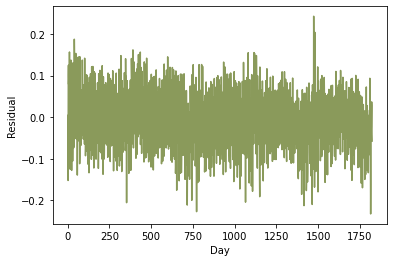

```python
model, residuals = build_model(base_vars+['demand_lag_1_day'])
print(model.summary())
plt_residual(residuals)
```

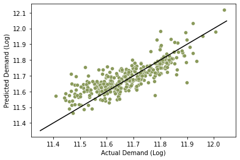

```python
sns.scatterplot(x=df_filtered['demand'], y=predictions[0], color = '#8A9A5B')
x_var = np.linspace(min(df_filtered['demand']), max(df_filtered['demand']))
y_var = x_var
plt.plot(x_var, y_var, color='black')
plt.xlabel('Actual Demand (Log)')
plt.ylabel('Predicted Demand (Log)')
```

#### 3.4.2 Adding 7_day lag

```python
df_filtered['demand_lag_7_day']=df_filtered['demand'].shift(7)

predictions = pd.DataFrame()
sse = 0
for date in all_dates:
    model, residuals = build_model(base_vars+['demand_lag_1_day', 'demand_lag_7_day'])
    subset = df_filtered[df_filtered['date'] == date]
    temp = model.predict(sm.add_constant(subset[base_vars+['demand_lag_1_day', 'demand_lag_7_day']], has_constant='add'))
    sse += ((np.exp(subset['demand']) - np.exp(temp.values))**2).sum()
    predictions = pd.concat([predictions, temp])
```

```python
np.sqrt(sse/365)
```

```
7332.064277590886
```

```
                            OLS Regression Results
==============================================================================
Dep. Variable:                 demand   R-squared:                       0.745
Model:                            OLS   Adj. R-squared:                  0.743
Method:                 Least Squares   F-statistic:                     478.7
Date:                Mon, 13 Mar 2023   Prob (F-statistic):               0.00
Time:                        17:19:34   Log-Likelihood:                 2605.8
No. Observations:                1817   AIC:                            -5188.
Df Residuals:                    1805   BIC:                            -5122.
Df Model:                          11
Covariance Type:            nonrobust
===========================================================================================
                              coef    std err          t      P>|t|      [0.025      0.975]
-------------------------------------------------------------------------------------------
const                       3.8913      0.203     19.207      0.000       3.494       4.289
max_temperature            -0.0327      0.002    -20.341      0.000      -0.036      -0.030
max_temperature_squared     0.0007   3.16e-05     23.672      0.000       0.001       0.001
min_temperature            -0.0118      0.002     -7.045      0.000      -0.015      -0.009
min_temperature_squared     0.0005    6.6e-05      7.148      0.000       0.000       0.001
solar_exposure             -0.0041      0.001     -4.820      0.000      -0.006      -0.002
solar_exposure_squared   9.251e-05   2.37e-05      3.902      0.000     4.6e-05       0.000
school_day                  0.0099      0.003      3.058      0.002       0.004       0.016
holiday                    -0.0987      0.008    -13.072      0.000      -0.114      -0.084
rainfall                   -0.0022      0.000     -5.944      0.000      -0.003      -0.001
demand_lag_1_day            0.3079      0.016     19.564      0.000       0.277       0.339
demand_lag_7_day            0.3958      0.014     28.838      0.000       0.369       0.423
==============================================================================
Omnibus:                       58.799   Durbin-Watson:                   1.352
Prob(Omnibus):                  0.000   Jarque-Bera (JB):               94.759
Skew:                          -0.285   Prob(JB):                     2.65e-21
Kurtosis:                       3.962   Cond. No.                     1.01e+05
==============================================================================

Notes:
[1] Standard Errors assume that the covariance matrix of the errors is correctly specified.
[2] The condition number is large, 1.01e+05. This might indicate that there are
strong multicollinearity or other numerical problems.
```

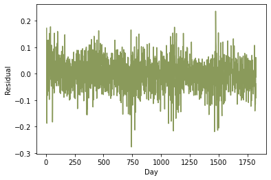

```python
model, residuals = build_model(base_vars+['demand_lag_1_day', 'demand_lag_7_day'])
print(model.summary())
plt_residual(residuals)
```

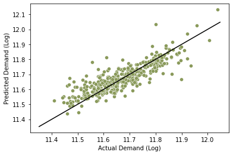

```python
sns.scatterplot(x=df_filtered['demand'], y=predictions[0], color = '#8A9A5B')
x_var = np.linspace(min(df_filtered['demand']), max(df_filtered['demand']))
y_var = x_var
plt.plot(x_var, y_var, color='black')
plt.xlabel('Actual Demand (Log)')
plt.ylabel('Predicted Demand (Log)')
```

#### 3.4.3 Adding 14_day lag

```python
df_filtered['demand_lag_14_day']=df_filtered['demand'].shift(14)

predictions = pd.DataFrame()
sse = 0
for date in all_dates:
    model, residuals = build_model(base_vars+['demand_lag_1_day', 'demand_lag_7_day', 'demand_lag_14_day'])
    subset = df_filtered[df_filtered['date'] == date]
    temp = model.predict(sm.add_constant(subset[base_vars+['demand_lag_1_day', 'demand_lag_7_day', 'demand_lag_14_day']], has_constant='add'))
    sse += ((np.exp(subset['demand']) - np.exp(temp.values))**2).sum()
    predictions = pd.concat([predictions, temp])
```

```python
np.sqrt(sse/365)
```

```
6956.357979913341
```

```
                            OLS Regression Results
==============================================================================
Dep. Variable:                 demand   R-squared:                       0.775
Model:                            OLS   Adj. R-squared:                  0.773
Method:                 Least Squares   F-statistic:                     515.3
Date:                Mon, 13 Mar 2023   Prob (F-statistic):               0.00
Time:                        17:19:51   Log-Likelihood:                 2709.4
No. Observations:                1810   AIC:                            -5393.
Df Residuals:                    1797   BIC:                            -5321.
Df Model:                          12
Covariance Type:            nonrobust
===========================================================================================
                              coef    std err          t      P>|t|      [0.025      0.975]
-------------------------------------------------------------------------------------------
const                       3.0532      0.198     15.390      0.000       2.664       3.442
max_temperature            -0.0318      0.002    -20.927      0.000      -0.035      -0.029
max_temperature_squared     0.0007   2.98e-05     24.564      0.000       0.001       0.001
min_temperature            -0.0122      0.002     -7.698      0.000      -0.015      -0.009
min_temperature_squared     0.0005   6.23e-05      7.953      0.000       0.000       0.001
solar_exposure             -0.0047      0.001     -5.845      0.000      -0.006      -0.003
solar_exposure_squared      0.0001   2.24e-05      4.968      0.000    6.74e-05       0.000
school_day                  0.0099      0.003      3.226      0.001       0.004       0.016
holiday                    -0.1026      0.007    -14.444      0.000      -0.117      -0.089
rainfall                   -0.0018      0.000     -5.321      0.000      -0.003      -0.001
demand_lag_1_day            0.2710      0.015     18.044      0.000       0.242       0.300
demand_lag_7_day            0.2864      0.015     19.027      0.000       0.257       0.316
demand_lag_14_day           0.2172      0.015     14.738      0.000       0.188       0.246
==============================================================================
Omnibus:                       47.316   Durbin-Watson:                   1.251
Prob(Omnibus):                  0.000   Jarque-Bera (JB):               90.727
Skew:                          -0.167   Prob(JB):                     1.99e-20
Kurtosis:                       4.045   Cond. No.                     1.05e+05
==============================================================================

Notes:
[1] Standard Errors assume that the covariance matrix of the errors is correctly specified.
[2] The condition number is large, 1.05e+05. This might indicate that there are
strong multicollinearity or other numerical problems.
```

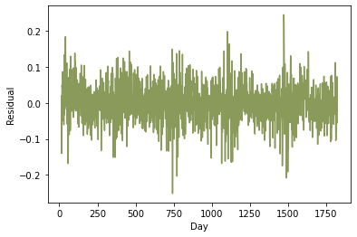

```python
model, residuals = build_model(base_vars+['demand_lag_1_day', 'demand_lag_7_day', 'demand_lag_14_day'])
print(model.summary())
plt_residual(residuals)
```

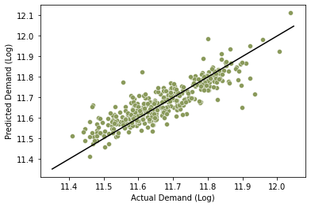

```python
sns.scatterplot(x=df_filtered['demand'], y=predictions[0], color = '#8A9A5B')
x_var = np.linspace(min(df_filtered['demand']), max(df_filtered['demand']))
y_var = x_var
plt.plot(x_var, y_var, color='black')
plt.xlabel('Actual Demand (Log)')
plt.ylabel('Predicted Demand (Log)')
```